# Risk Factor Analysis

## Outcome Variable

**Outcome Variable:** ever_wasted

## Predictor Variables

**Intervention Variable:** predfeed6

**Adjustment Set:**

- arm
- sex
- month
- brthmon
- W_mage
- meducyrs
- feducyrs
- hhwealth_quart
- hfoodsec
- W_mhtcm
- W_mwtkg
- W_mbmi
- vagbrth
- W_gagebrth
- W_birthwt
- W_birthlen
- W_nrooms
- W_nchldlt5
- W_parity
- impfloor
- impsan
- safeh20
- delta_W_mage
- delta_meducyrs
- delta_feducyrs
- delta_hhwealth_quart
- delta_hfoodsec
- delta_W_mhtcm
- delta_W_mwtkg
- delta_W_mbmi
- delta_vagbrth
- delta_W_gagebrth
- delta_W_birthwt
- delta_W_birthlen
- delta_W_nrooms
- delta_W_nchldlt5
- delta_W_parity
- delta_impfloor
- delta_impsan
- delta_safeh20

## Stratifying Variables

The analysis was stratified on these variable(s):

- agecat
- studyid
- country

## Data Summary

| agecat | studyid | country | predfeed6 | ever_wasted | n_cell | n |
| --- | --- | --- | --- | --- | --- | --- |
| 0-24 months (no birth wast) | EE | PAKISTAN | 1 | 0 | 21 | 48 |
| 0-24 months (no birth wast) | EE | PAKISTAN | 1 | 1 | 22 | 48 |
| 0-24 months (no birth wast) | EE | PAKISTAN | 0 | 0 | 3 | 48 |
| 0-24 months (no birth wast) | EE | PAKISTAN | 0 | 1 | 2 | 48 |
| 0-24 months (no birth wast) | GMS-Nepal | NEPAL | 1 | 0 | 176 | 560 |
| 0-24 months (no birth wast) | GMS-Nepal | NEPAL | 1 | 1 | 241 | 560 |
| 0-24 months (no birth wast) | GMS-Nepal | NEPAL | 0 | 0 | 66 | 560 |
| 0-24 months (no birth wast) | GMS-Nepal | NEPAL | 0 | 1 | 77 | 560 |
| 0-24 months (no birth wast) | JiVitA-3 | BANGLADESH | 1 | 0 | 10160 | 15666 |
| 0-24 months (no birth wast) | JiVitA-3 | BANGLADESH | 1 | 1 | 2046 | 15666 |
| 0-24 months (no birth wast) | JiVitA-3 | BANGLADESH | 0 | 0 | 2829 | 15666 |
| 0-24 months (no birth wast) | JiVitA-3 | BANGLADESH | 0 | 1 | 631 | 15666 |
| 0-24 months (no birth wast) | JiVitA-4 | BANGLADESH | 1 | 0 | 2753 | 4722 |
| 0-24 months (no birth wast) | JiVitA-4 | BANGLADESH | 1 | 1 | 927 | 4722 |
| 0-24 months (no birth wast) | JiVitA-4 | BANGLADESH | 0 | 0 | 736 | 4722 |
| 0-24 months (no birth wast) | JiVitA-4 | BANGLADESH | 0 | 1 | 306 | 4722 |
| 0-24 months (no birth wast) | LCNI-5 | MALAWI | 1 | 0 | 42 | 271 |
| 0-24 months (no birth wast) | LCNI-5 | MALAWI | 1 | 1 | 5 | 271 |
| 0-24 months (no birth wast) | LCNI-5 | MALAWI | 0 | 0 | 204 | 271 |
| 0-24 months (no birth wast) | LCNI-5 | MALAWI | 0 | 1 | 20 | 271 |
| 0-24 months (no birth wast) | MAL-ED | BANGLADESH | 1 | 0 | 62 | 233 |
| 0-24 months (no birth wast) | MAL-ED | BANGLADESH | 1 | 1 | 23 | 233 |
| 0-24 months (no birth wast) | MAL-ED | BANGLADESH | 0 | 0 | 116 | 233 |
| 0-24 months (no birth wast) | MAL-ED | BANGLADESH | 0 | 1 | 32 | 233 |
| 0-24 months (no birth wast) | MAL-ED | BRAZIL | 1 | 0 | 29 | 210 |
| 0-24 months (no birth wast) | MAL-ED | BRAZIL | 1 | 1 | 1 | 210 |
| 0-24 months (no birth wast) | MAL-ED | BRAZIL | 0 | 0 | 168 | 210 |
| 0-24 months (no birth wast) | MAL-ED | BRAZIL | 0 | 1 | 12 | 210 |
| 0-24 months (no birth wast) | MAL-ED | INDIA | 1 | 0 | 10 | 216 |
| 0-24 months (no birth wast) | MAL-ED | INDIA | 1 | 1 | 1 | 216 |

[output cut: 74 more lines]

The following strata were considered:

- agecat: 0-24 months (no birth wast), studyid: EE, country: PAKISTAN
- agecat: 0-24 months (no birth wast), studyid: GMS-Nepal, country: NEPAL
- agecat: 0-24 months (no birth wast), studyid: JiVitA-3, country: BANGLADESH
- agecat: 0-24 months (no birth wast), studyid: JiVitA-4, country: BANGLADESH
- agecat: 0-24 months (no birth wast), studyid: LCNI-5, country: MALAWI
- agecat: 0-24 months (no birth wast), studyid: MAL-ED, country: BANGLADESH
- agecat: 0-24 months (no birth wast), studyid: MAL-ED, country: BRAZIL
- agecat: 0-24 months (no birth wast), studyid: MAL-ED, country: INDIA
- agecat: 0-24 months (no birth wast), studyid: MAL-ED, country: NEPAL
- agecat: 0-24 months (no birth wast), studyid: MAL-ED, country: PERU
- agecat: 0-24 months (no birth wast), studyid: MAL-ED, country: SOUTH AFRICA
- agecat: 0-24 months (no birth wast), studyid: MAL-ED, country: TANZANIA, UNITED REPUBLIC OF
- agecat: 0-24 months (no birth wast), studyid: SAS-FoodSuppl, country: INDIA
- agecat: 0-6 months (no birth wast), studyid: EE, country: PAKISTAN
- agecat: 0-6 months (no birth wast), studyid: GMS-Nepal, country: NEPAL
- agecat: 0-6 months (no birth wast), studyid: JiVitA-3, country: BANGLADESH
- agecat: 0-6 months (no birth wast), studyid: JiVitA-4, country: BANGLADESH
- agecat: 0-6 months (no birth wast), studyid: LCNI-5, country: MALAWI
- agecat: 0-6 months (no birth wast), studyid: MAL-ED, country: BANGLADESH
- agecat: 0-6 months (no birth wast), studyid: MAL-ED, country: BRAZIL
- agecat: 0-6 months (no birth wast), studyid: MAL-ED, country: INDIA
- agecat: 0-6 months (no birth wast), studyid: MAL-ED, country: NEPAL
- agecat: 0-6 months (no birth wast), studyid: MAL-ED, country: PERU
- agecat: 0-6 months (no birth wast), studyid: MAL-ED, country: SOUTH AFRICA
- agecat: 0-6 months (no birth wast), studyid: MAL-ED, country: TANZANIA, UNITED REPUBLIC OF
- agecat: 0-6 months (no birth wast), studyid: SAS-FoodSuppl, country: INDIA

### Dropped Strata

Some strata were dropped due to rare outcomes:

- agecat: 0-24 months (no birth wast), studyid: EE, country: PAKISTAN
- agecat: 0-24 months (no birth wast), studyid: MAL-ED, country: BRAZIL
- agecat: 0-24 months (no birth wast), studyid: MAL-ED, country: INDIA
- agecat: 0-24 months (no birth wast), studyid: MAL-ED, country: NEPAL
- agecat: 0-24 months (no birth wast), studyid: MAL-ED, country: SOUTH AFRICA
- agecat: 0-24 months (no birth wast), studyid: MAL-ED, country: TANZANIA, UNITED REPUBLIC OF
- agecat: 0-24 months (no birth wast), studyid: SAS-FoodSuppl, country: INDIA
- agecat: 0-6 months (no birth wast), studyid: EE, country: PAKISTAN
- agecat: 0-6 months (no birth wast), studyid: LCNI-5, country: MALAWI
- agecat: 0-6 months (no birth wast), studyid: MAL-ED, country: BRAZIL
- agecat: 0-6 months (no birth wast), studyid: MAL-ED, country: INDIA
- agecat: 0-6 months (no birth wast), studyid: MAL-ED, country: NEPAL
- agecat: 0-6 months (no birth wast), studyid: MAL-ED, country: PERU
- agecat: 0-6 months (no birth wast), studyid: MAL-ED, country: SOUTH AFRICA
- agecat: 0-6 months (no birth wast), studyid: MAL-ED, country: TANZANIA, UNITED REPUBLIC OF
- agecat: 0-6 months (no birth wast), studyid: SAS-FoodSuppl, country: INDIA

## Methods Detail

We're interested in the causal parameters $E[Y_a]$ for all values of $a \in \mathcal{A}$. These parameters represent the mean outcome if, possibly contrary to fact, we intervened to set all units to have $A=a$. Under the randomization and positivity assumptions, these are identified by the statistical parameters $\psi_a=E_W[E_{Y|A,W}(Y|A=a,W)]$. In addition, we're interested in the mean of $Y$, $E[Y]$ under no intervention (the observed mean). We will estimate these parameters by using SuperLearner to fit the relevant likelihood factors -- $E_{Y|A,W}(Y|A=a,W)$ and $p(A=a|W)$, and then updating our likelihood fit using a joint TMLE.

For unadjusted analyses ($W=\{\}$), initial likelihoods were estimated using Lrnr_glm to estimate the simple $E(Y|A)$ and Lrnr_mean to estimate $p(A)$. For adjusted analyses, a small library containing Lrnr_glmnet, Lrnr_xgboost, and Lrnr_mean was used.

Having estimated these parameters, we will then use the delta method to estimate relative risks and attributable risks relative to a prespecified baseline level of $A$.

# Results Detail

## Results Plots

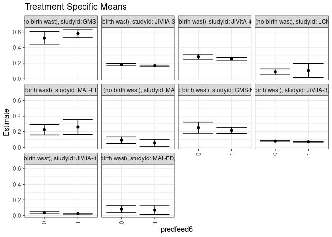

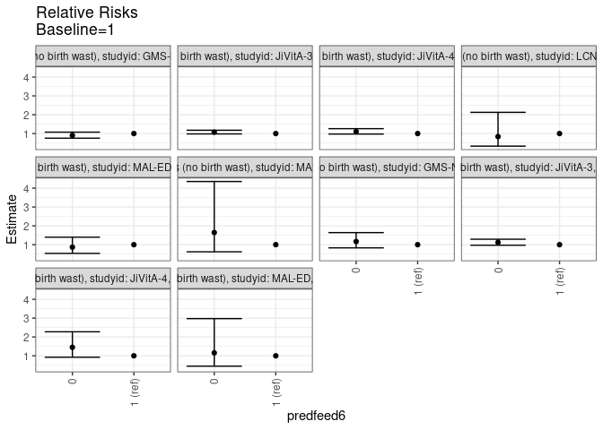

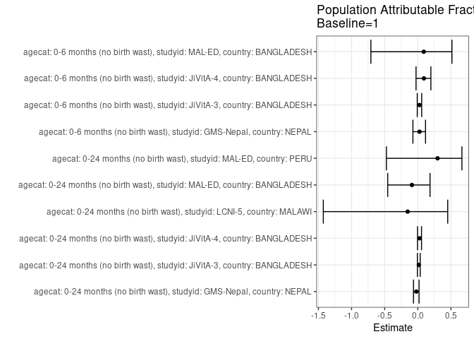

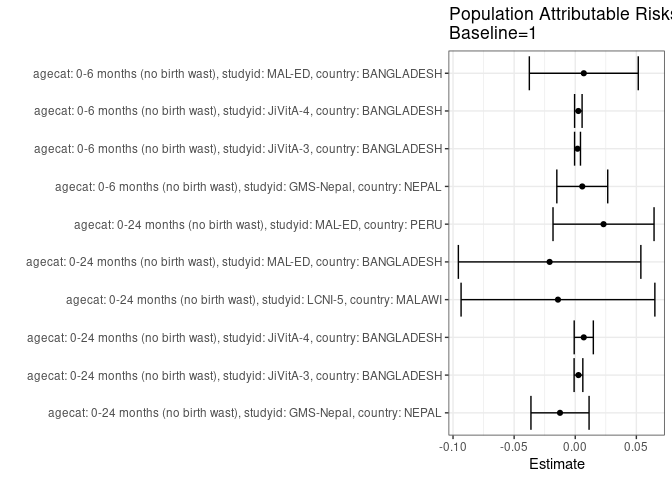

## Results Table

### Parameter: TSM

| agecat | studyid | country | intervention_level | baseline_level | estimate | ci_lower | ci_upper |
| --- | --- | --- | --- | --- | --- | --- | --- |
| 0-24 months (no birth wast) | GMS-Nepal | NEPAL | 1 | NA | 0.5803260 | 0.5331135 | 0.6275385 |
| 0-24 months (no birth wast) | GMS-Nepal | NEPAL | 0 | NA | 0.5228287 | 0.4406880 | 0.6049694 |
| 0-24 months (no birth wast) | JiVitA-3 | BANGLADESH | 1 | NA | 0.1682435 | 0.1610708 | 0.1754162 |
| 0-24 months (no birth wast) | JiVitA-3 | BANGLADESH | 0 | NA | 0.1805199 | 0.1662488 | 0.1947911 |
| 0-24 months (no birth wast) | JiVitA-4 | BANGLADESH | 1 | NA | 0.2541485 | 0.2374265 | 0.2708705 |
| 0-24 months (no birth wast) | JiVitA-4 | BANGLADESH | 0 | NA | 0.2813339 | 0.2496713 | 0.3129965 |
| 0-24 months (no birth wast) | LCNI-5 | MALAWI | 1 | NA | 0.1063830 | 0.0180722 | 0.1946938 |
| 0-24 months (no birth wast) | LCNI-5 | MALAWI | 0 | NA | 0.0892857 | 0.0518739 | 0.1266975 |
| 0-24 months (no birth wast) | MAL-ED | BANGLADESH | 1 | NA | 0.2570291 | 0.1606563 | 0.3534020 |
| 0-24 months (no birth wast) | MAL-ED | BANGLADESH | 0 | NA | 0.2229083 | 0.1559831 | 0.2898335 |
| 0-24 months (no birth wast) | MAL-ED | PERU | 1 | NA | 0.0543478 | 0.0079376 | 0.1007581 |
| 0-24 months (no birth wast) | MAL-ED | PERU | 0 | NA | 0.0893855 | 0.0475133 | 0.1312576 |
| 0-6 months (no birth wast) | GMS-Nepal | NEPAL | 1 | NA | 0.2129996 | 0.1732339 | 0.2527653 |
| 0-6 months (no birth wast) | GMS-Nepal | NEPAL | 0 | NA | 0.2485260 | 0.1778666 | 0.3191854 |
| 0-6 months (no birth wast) | JiVitA-3 | BANGLADESH | 1 | NA | 0.0700459 | 0.0649242 | 0.0751676 |
| 0-6 months (no birth wast) | JiVitA-3 | BANGLADESH | 0 | NA | 0.0783913 | 0.0685247 | 0.0882579 |
| 0-6 months (no birth wast) | JiVitA-4 | BANGLADESH | 1 | NA | 0.0248980 | 0.0188771 | 0.0309189 |
| 0-6 months (no birth wast) | JiVitA-4 | BANGLADESH | 0 | NA | 0.0361352 | 0.0229667 | 0.0493036 |
| 0-6 months (no birth wast) | MAL-ED | BANGLADESH | 1 | NA | 0.0705882 | 0.0160191 | 0.1251573 |
| 0-6 months (no birth wast) | MAL-ED | BANGLADESH | 0 | NA | 0.0816327 | 0.0372751 | 0.1259902 |

### Parameter: E(Y)

| agecat | studyid | country | intervention_level | baseline_level | estimate | ci_lower | ci_upper |
| --- | --- | --- | --- | --- | --- | --- | --- |
| 0-24 months (no birth wast) | GMS-Nepal | NEPAL | NA | NA | 0.5678571 | 0.5267918 | 0.6089225 |
| 0-24 months (no birth wast) | JiVitA-3 | BANGLADESH | NA | NA | 0.1708796 | 0.1645476 | 0.1772116 |
| 0-24 months (no birth wast) | JiVitA-4 | BANGLADESH | NA | NA | 0.2611182 | 0.2462845 | 0.2759518 |
| 0-24 months (no birth wast) | LCNI-5 | MALAWI | NA | NA | 0.0922509 | 0.0577338 | 0.1267680 |
| 0-24 months (no birth wast) | MAL-ED | BANGLADESH | NA | NA | 0.2360515 | 0.1814079 | 0.2906951 |
| 0-24 months (no birth wast) | MAL-ED | PERU | NA | NA | 0.0774908 | 0.0455992 | 0.1093824 |
| 0-6 months (no birth wast) | GMS-Nepal | NEPAL | NA | NA | 0.2187500 | 0.1839790 | 0.2535210 |
| 0-6 months (no birth wast) | JiVitA-3 | BANGLADESH | NA | NA | 0.0719114 | 0.0672720 | 0.0765508 |
| 0-6 months (no birth wast) | JiVitA-4 | BANGLADESH | NA | NA | 0.0274331 | 0.0219967 | 0.0328694 |
| 0-6 months (no birth wast) | MAL-ED | BANGLADESH | NA | NA | 0.0775862 | 0.0430879 | 0.1120845 |

### Parameter: RR

| agecat | studyid | country | intervention_level | baseline_level | estimate | ci_lower | ci_upper |
| --- | --- | --- | --- | --- | --- | --- | --- |
| 0-24 months (no birth wast) | GMS-Nepal | NEPAL | 1 | 1 | 1.0000000 | 1.0000000 | 1.000000 |
| 0-24 months (no birth wast) | GMS-Nepal | NEPAL | 0 | 1 | 0.9009224 | 0.7557254 | 1.074016 |
| 0-24 months (no birth wast) | JiVitA-3 | BANGLADESH | 1 | 1 | 1.0000000 | 1.0000000 | 1.000000 |
| 0-24 months (no birth wast) | JiVitA-3 | BANGLADESH | 0 | 1 | 1.0729683 | 0.9798061 | 1.174988 |
| 0-24 months (no birth wast) | JiVitA-4 | BANGLADESH | 1 | 1 | 1.0000000 | 1.0000000 | 1.000000 |
| 0-24 months (no birth wast) | JiVitA-4 | BANGLADESH | 0 | 1 | 1.1069664 | 0.9726171 | 1.259874 |
| 0-24 months (no birth wast) | LCNI-5 | MALAWI | 1 | 1 | 1.0000000 | 1.0000000 | 1.000000 |
| 0-24 months (no birth wast) | LCNI-5 | MALAWI | 0 | 1 | 0.8392857 | 0.3311837 | 2.126918 |
| 0-24 months (no birth wast) | MAL-ED | BANGLADESH | 1 | 1 | 1.0000000 | 1.0000000 | 1.000000 |
| 0-24 months (no birth wast) | MAL-ED | BANGLADESH | 0 | 1 | 0.8672490 | 0.5384202 | 1.396903 |
| 0-24 months (no birth wast) | MAL-ED | PERU | 1 | 1 | 1.0000000 | 1.0000000 | 1.000000 |
| 0-24 months (no birth wast) | MAL-ED | PERU | 0 | 1 | 1.6446927 | 0.6209888 | 4.355979 |
| 0-6 months (no birth wast) | GMS-Nepal | NEPAL | 1 | 1 | 1.0000000 | 1.0000000 | 1.000000 |
| 0-6 months (no birth wast) | GMS-Nepal | NEPAL | 0 | 1 | 1.1667910 | 0.8298522 | 1.640535 |
| 0-6 months (no birth wast) | JiVitA-3 | BANGLADESH | 1 | 1 | 1.0000000 | 1.0000000 | 1.000000 |
| 0-6 months (no birth wast) | JiVitA-3 | BANGLADESH | 0 | 1 | 1.1191421 | 0.9705371 | 1.290501 |
| 0-6 months (no birth wast) | JiVitA-4 | BANGLADESH | 1 | 1 | 1.0000000 | 1.0000000 | 1.000000 |
| 0-6 months (no birth wast) | JiVitA-4 | BANGLADESH | 0 | 1 | 1.4513278 | 0.9254770 | 2.275964 |
| 0-6 months (no birth wast) | MAL-ED | BANGLADESH | 1 | 1 | 1.0000000 | 1.0000000 | 1.000000 |
| 0-6 months (no birth wast) | MAL-ED | BANGLADESH | 0 | 1 | 1.1564626 | 0.4495261 | 2.975146 |

### Parameter: PAR

| agecat | studyid | country | intervention_level | baseline_level | estimate | ci_lower | ci_upper |
| --- | --- | --- | --- | --- | --- | --- | --- |
| 0-24 months (no birth wast) | GMS-Nepal | NEPAL | 1 | NA | -0.0124689 | -0.0362460 | 0.0113083 |
| 0-24 months (no birth wast) | JiVitA-3 | BANGLADESH | 1 | NA | 0.0026361 | -0.0009299 | 0.0062021 |
| 0-24 months (no birth wast) | JiVitA-4 | BANGLADESH | 1 | NA | 0.0069696 | -0.0008571 | 0.0147963 |
| 0-24 months (no birth wast) | LCNI-5 | MALAWI | 1 | NA | -0.0141321 | -0.0934107 | 0.0651466 |
| 0-24 months (no birth wast) | MAL-ED | BANGLADESH | 1 | NA | -0.0209776 | -0.0956389 | 0.0536836 |
| 0-24 months (no birth wast) | MAL-ED | PERU | 1 | NA | 0.0231429 | -0.0181917 | 0.0644776 |
| 0-6 months (no birth wast) | GMS-Nepal | NEPAL | 1 | NA | 0.0057504 | -0.0150739 | 0.0265747 |
| 0-6 months (no birth wast) | JiVitA-3 | BANGLADESH | 1 | NA | 0.0018655 | -0.0005447 | 0.0042758 |
| 0-6 months (no birth wast) | JiVitA-4 | BANGLADESH | 1 | NA | 0.0025351 | -0.0005305 | 0.0056006 |
| 0-6 months (no birth wast) | MAL-ED | BANGLADESH | 1 | NA | 0.0069980 | -0.0375657 | 0.0515616 |

### Parameter: PAF

| agecat | studyid | country | intervention_level | baseline_level | estimate | ci_lower | ci_upper |
| --- | --- | --- | --- | --- | --- | --- | --- |
| 0-24 months (no birth wast) | GMS-Nepal | NEPAL | 1 | NA | -0.0219578 | -0.0647497 | 0.0191143 |
| 0-24 months (no birth wast) | JiVitA-3 | BANGLADESH | 1 | NA | 0.0154267 | -0.0056552 | 0.0360665 |
| 0-24 months (no birth wast) | JiVitA-4 | BANGLADESH | 1 | NA | 0.0266915 | -0.0037769 | 0.0562351 |
| 0-24 months (no birth wast) | LCNI-5 | MALAWI | 1 | NA | -0.1531915 | -1.4265796 | 0.4519650 |
| 0-24 months (no birth wast) | MAL-ED | BANGLADESH | 1 | NA | -0.0888689 | -0.4543298 | 0.1847547 |
| 0-24 months (no birth wast) | MAL-ED | PERU | 1 | NA | 0.2986542 | -0.4737013 | 0.6662242 |
| 0-6 months (no birth wast) | GMS-Nepal | NEPAL | 1 | NA | 0.0262877 | -0.0736239 | 0.1169015 |
| 0-6 months (no birth wast) | JiVitA-3 | BANGLADESH | 1 | NA | 0.0259421 | -0.0081161 | 0.0588496 |
| 0-6 months (no birth wast) | JiVitA-4 | BANGLADESH | 1 | NA | 0.0924086 | -0.0265284 | 0.1975652 |
| 0-6 months (no birth wast) | MAL-ED | BANGLADESH | 1 | NA | 0.0901961 | -0.7082806 | 0.5154524 |